# Version control and git the basics of git commit

10/26/2018

## Versioning: the problem

- …
- thesis-final
- thesis-final2,thesis-final3, thesis-final4, thesis-final4-corr
- thesis-final-final
- …
- thesis-final-final-corr_Prof-3-submitted-rev2 ?

## Version control: manual solution

- Increasing numbers: 01-99, or 001-999 or ISO date (end or beginning of file name)
- Version history file: log of changes
- Also possible: all old version in a sub-folder, keep only last version in the main folder.

## Results

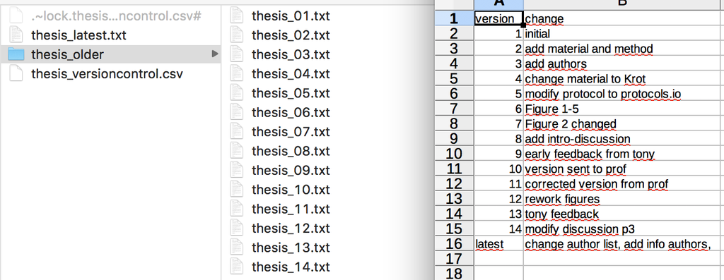

## Automation via Git

- "git commit"" is like
  - adding a snapshot of file in an invisible folder
  - writing a comment in the version history
- Result:
  - Only latest version visible
  - All version saved (although less accessible)
  - Version history, with messages
- In addition:
  - Deleted files are still there somewhere !
  - only changes are saved in the snapshot -> need less storage space  
    !! work with text files only, not binaries (.csv, .txt, .md but not .docs, .xlsx, .jpg,… files)

## git commit, principle

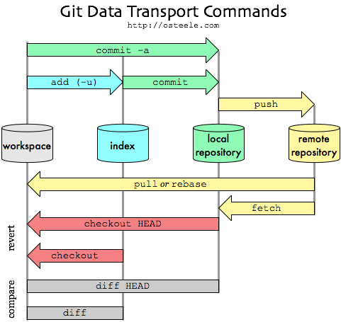

## git commit, in Rstudio

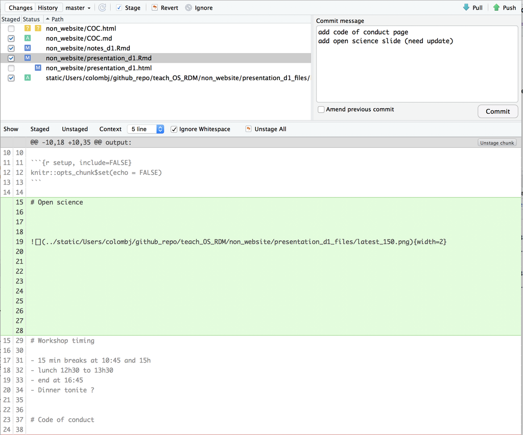

## Version history

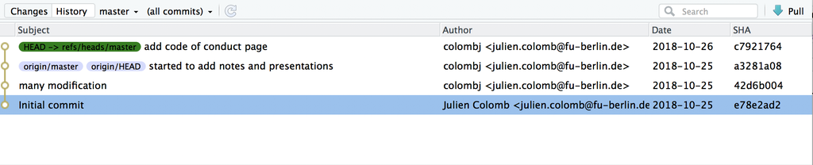

## Using git in practice

- Command lines for nerds !
- Rstudio (github desktop,…), for creation, commits and simple stuff
- Git specific software (Sourcetree, tortoise,…) for more complex processes (merge, complex history,…)
- Problems -> google error message -> stack overflow solution (mostly via git commands, shell button on Rstudio)